# Lab 6: MATH 4753

Hunter DeVoe

February 8, 2023

# Task 1

```r
getwd()
```

```
## [1] "/home/eclipse/Desktop/Math 4753 Labs/Lab 6"
```

# Task 2

## Use layout() to construct a plotting region that will take 4 plots. Use it to plot 4 normal curves with the following parameters.

- $\mu = 10, \sigma = 4$
- $\mu = 10, \sigma = 2$
- $\mu = 5, \sigma = 10$
- $\mu = 5, \sigma = \frac{1}{2}$

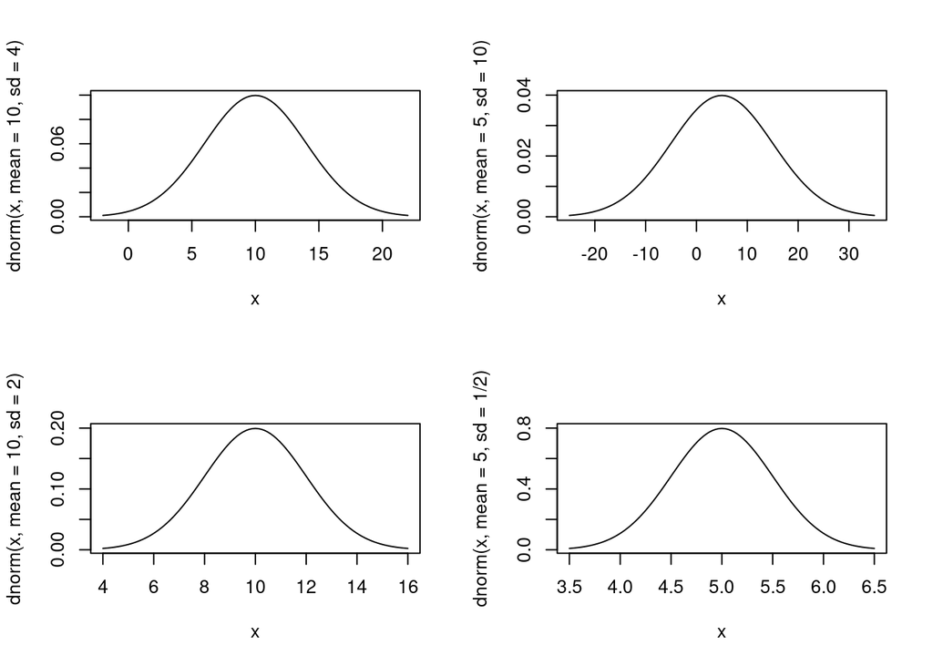

```r
layout(matrix(1:4, nr=2,nc=2))
curve(dnorm(x, mean=10,sd=4),xlim=c(10 - 3 * 4, 10 + 3 * 4))
curve(dnorm(x, mean=10,sd=2),xlim=c(10 - 3 * 2, 10 + 3 * 2))
curve(dnorm(x, mean=5,sd=10),xlim=c(5 - 3 * 10, 5 + 3 * 10))
curve(dnorm(x, mean=5,sd=1/2),xlim=c(5 - 3 * 0.5, 5 + 3 * 0.5))
```

## Plot the following regions and probabilities using one graphical interface per plot (use 4 dec. places)

- $Y \sim N(0, 1), P(Y \geq 2)$

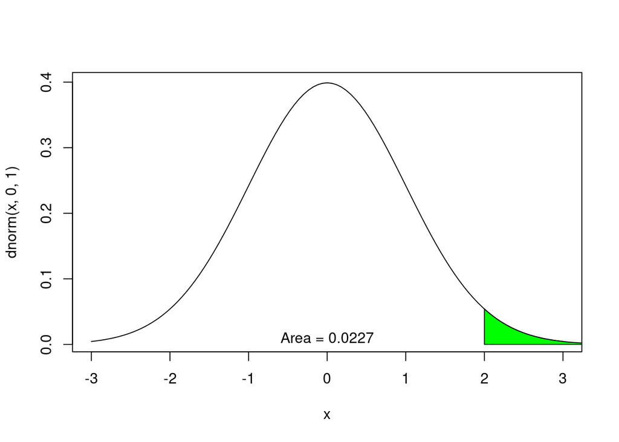

```r
curve(dnorm(x, 0, 1), xlim = c(-3, 3))
xcurve <- seq(2, 5, length = 1000)
ycurve <- dnorm(xcurve, 0, 1)
polygon(c(2, xcurve, 5), c(0, ycurve, 0), col = "Green")
area <- pnorm(5, 0, 1) - pnorm(2, 0, 1)
area <- round(area, 4)
text(0, 0.01, paste0("Area = ", area))
```

- $Y \sim N(\mu = 4, \sigma = 2), P(1 \leq Y < 5)$

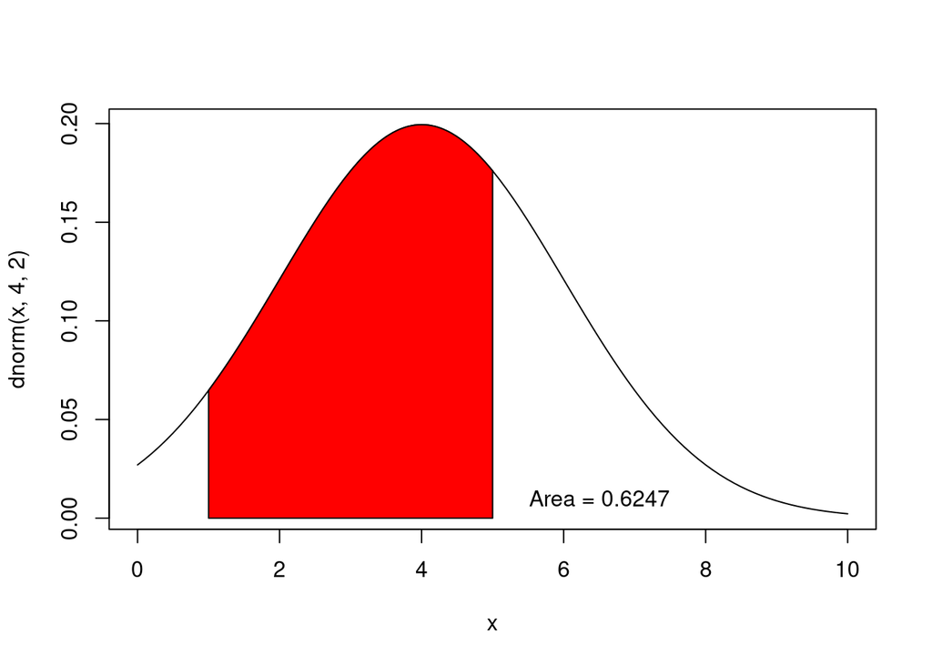

```r
curve(dnorm(x, 4, 2), xlim = c(0, 10))
xcurve <- seq(1, 5, length = 1000)
ycurve <- dnorm(xcurve, 4, 2)
polygon(c(1, xcurve, 5), c(0, ycurve, 0), col = "Red")
area <- pnorm(5, 4, 2) - pnorm(1, 4, 2)
area <- round(area, 4)
text(6.5, 0.01, paste0("Area = ", area))
```

- $Y \sim N(\mu = 10, \sigma = 4), P(Y < 10)$

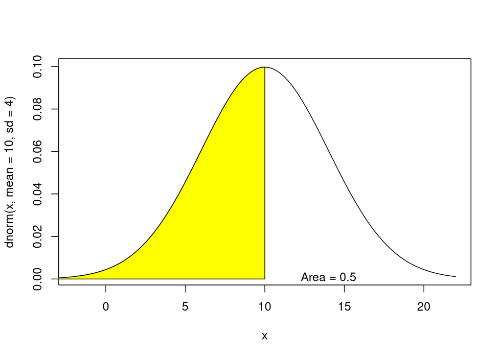

```r
curve(dnorm(x, mean = 10, sd = 4), xlim = c(-2, 22))
xcurve <- seq(-5, 10, length = 1000)
ycurve <- dnorm(xcurve, 10, 4)
polygon(c(-5, xcurve, 10), c(0, ycurve, 0), col = "Yellow")
area <- pnorm(10, 10, 4)
area <- round(area, 4)
text(14, 0.001, paste0("Area = ", area))
```

- $Y \sim N(\mu = -2, \sigma = \frac{1}{2}), P(-3 < Y \leq -2)$

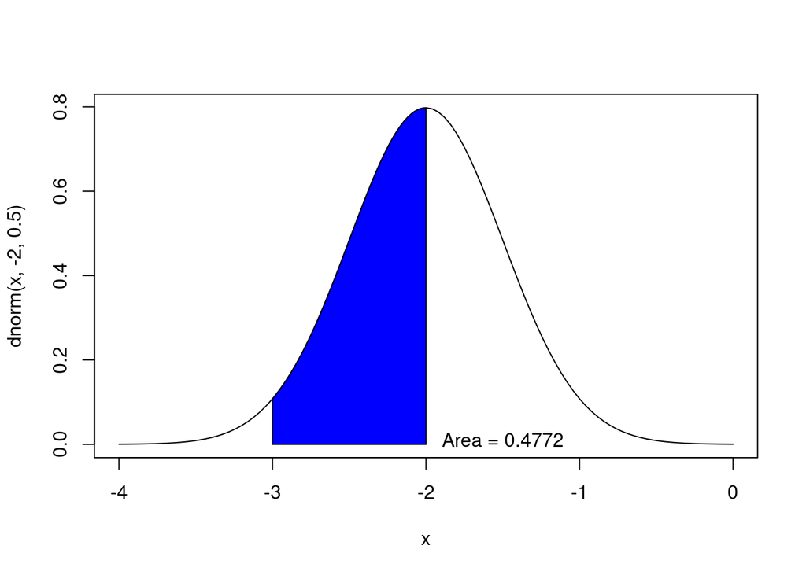

```r
curve(dnorm(x,-2, 0.5), xlim = c(-4, 0))
#P(-2 <= y < -1)
xcurve <- seq(-2, -3, length = 1000)
ycurve <- dnorm(xcurve, -2, 0.5)
polygon(c(-2, xcurve, -3), c(0, ycurve, 0), col = "Blue")
area <- pnorm(-2, -2, 0.5) - pnorm(-3, -2, 0.5)
area <- round(area, 4)
text(-1.5, 0.01, paste0("Area = ", area))
```

# Task 3

## On the one plotting surface, overlay the following three plots:

- $Y \sim Gamma(shape = 1, scale = 1)$
- $Y \sim Gamma(shape = 3, scale = 1)$
- $Y \sim Gamma(shape = 5, scale = 1)$

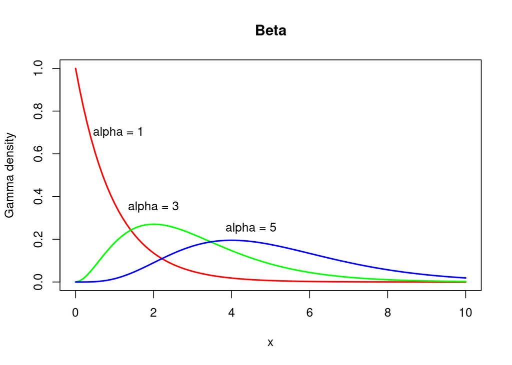

```r
curve(dgamma(x,shape=1,scale=1),xlim=c(0,10),ylim=c(0,1),col="Red",lwd=2,
ylab="Gamma density", main="Beta")
text(1.1, .7, paste0("alpha = ",1))
curve(dgamma(x,shape=3,scale=1),xlim=c(0,10),ylim=c(0,1),add=TRUE, col = "Green", lwd=2)
text(2, .35, paste0("alpha = ",3))
curve(dgamma(x,shape=5,scale=1),xlim=c(0,10),ylim=c(0,1),add=TRUE, col="Blue",lwd=2)
text(4.5, .25, paste0("alpha = ",5))
```

## Plot the following regions and probabilities in R

- $Y \sim Gamma(shape = 3, scale = 2), P(2 < Y < 5)$

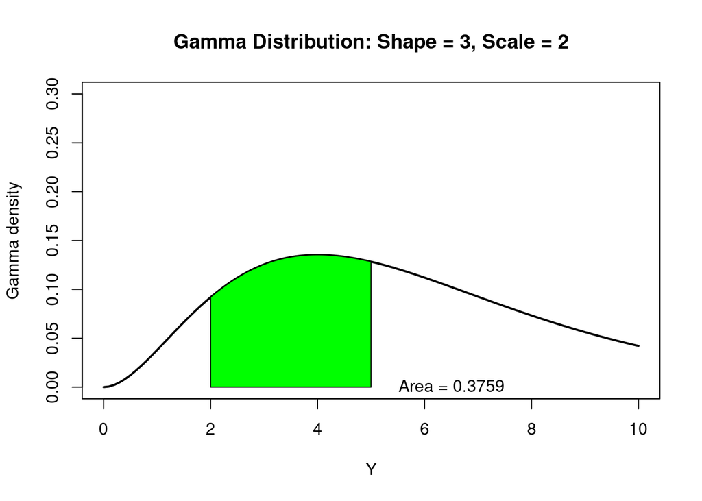

```r
curve(dgamma(x, shape = 3, scale = 2), xlim = c(0, 10), ylim = c(0, 0.3), lwd = 2, ylab = "Gamma density", xlab = "Y", main = "Gamma Distribution: Shape = 3, Scale = 2")
xcurve <- seq(2, 5, length = 1000)
ycurve <- dgamma(xcurve, shape = 3, scale = 2)
polygon(c(2, xcurve, 5), c(0, ycurve, 0), col = "Green")
area <- pgamma(5, shape = 3, scale = 2) - pgamma(2, shape = 3, scale = 2)
area <- round(area, 4)
text(6.5, 0.001, paste0("Area = ", area))
```

- $Y \sim Gamma(shape = 6, scale = 3), P(1 \leq Y \leq 4)$

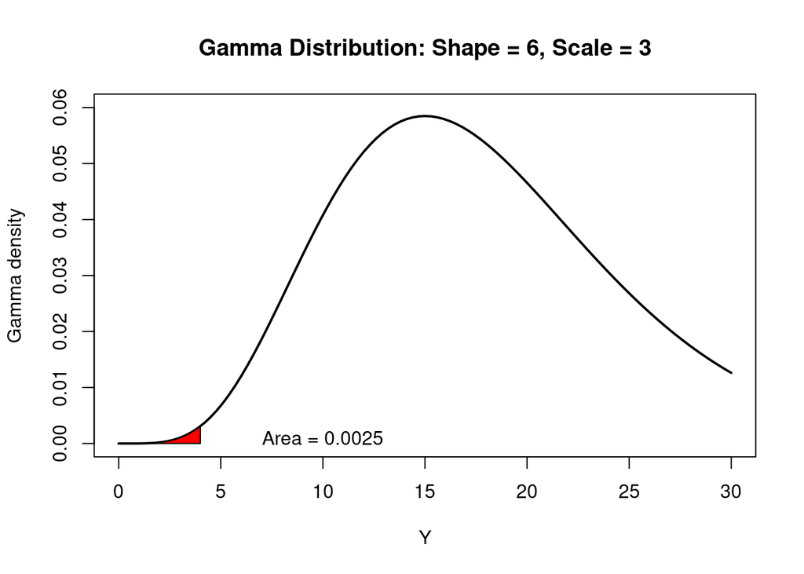

```r
curve(dgamma(x, shape = 6, scale = 3), xlim = c(0, 30), ylim=c(0, 0.06), lwd = 2, ylab="Gamma density", xlab = "Y", main = "Gamma Distribution: Shape = 6, Scale = 3")
xcurve <- seq(1, 4, length = 1000)
ycurve <- dgamma(xcurve, shape = 6, scale = 3)
polygon(c(1, xcurve, 4), c(0, ycurve, 0), col = "Red")
area <- pgamma(4, shape = 6, scale = 3) - pgamma(1, shape = 6, scale = 3)
area <- round(area, 4)
text(10, 0.001, paste0("Area = ", area))
```

- $Y \sim Gamma(shape = 2, scale = 4), P(3 \leq Y < 6)$

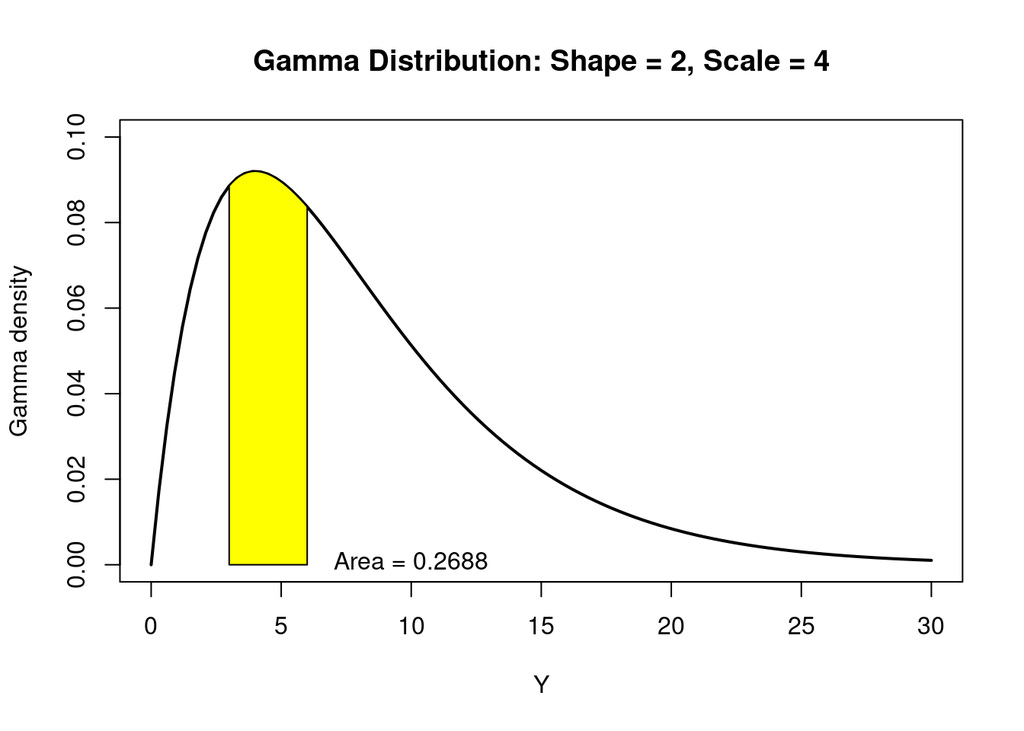

```r
curve(dgamma(x, shape = 2, scale = 4), xlim = c(0, 30), ylim=c(0, 0.1), lwd = 2, ylab="Gamma density", xlab = "Y", main = "Gamma Distribution: Shape = 2, Scale = 4")
xcurve <- seq(3, 6, length = 1000)
ycurve <- dgamma(xcurve, shape = 2, scale = 4)
polygon(c(3, xcurve, 6), c(0, ycurve, 0), col = "Yellow")
area <- pgamma(6, shape = 2, scale = 4) - pgamma(3, shape = 2, scale = 4)
area <- round(area, 4)
text(10, 0.001, paste0("Area = ", area))
```

## Task 4

### Use layout() and break up the graphical interface so that there are four squares to plot the following on:

- $Y \sim chisq(df = 1)$
- $Y \sim chisq(df = 2)$
- $Y \sim chisq(df = 4)$
- $Y \sim chisq(df = 20)$

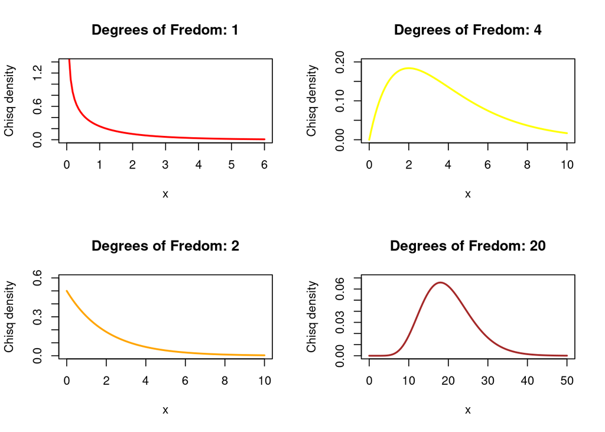

```r
layout(matrix(1:4, nr = 2, nc = 2))

curve(dchisq(x,df=1),xlim=c(0,6),ylim=c(0,1.4),col="Red",lwd=2,
ylab="Chisq density", main="Degrees of Fredom: 1")

curve(dchisq(x,df=2),xlim=c(0,10),ylim=c(0,0.6),col="Orange",lwd=2,
ylab="Chisq density", main="Degrees of Fredom: 2")

curve(dchisq(x,df=4),xlim=c(0,10),ylim=c(0,0.2),col="Yellow",lwd=2,
ylab="Chisq density", main="Degrees of Fredom: 4")

curve(dchisq(x,df=20),xlim=c(0,50),ylim=c(0,0.07),col="Brown",lwd=2,
ylab="Chisq density", main="Degrees of Fredom: 20")
```

### Plot the following regions and probabilities in R on separate plotting surfaces.

- $Y \sim chisq(df = 2), P(2 \leq Y \leq 4)$

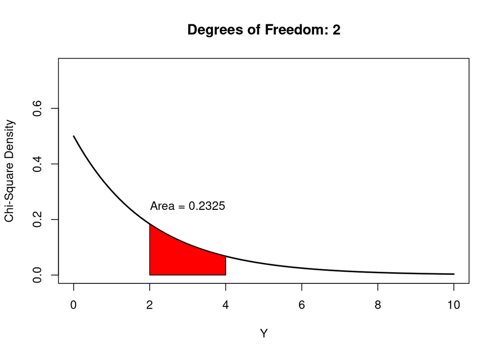

```r
curve(dchisq(x, df = 2), xlim = c(0, 10), ylim = c(0, 0.75), lwd = 2, xlab = "Y", ylab = "Chi-Square Density", main = "Degrees of Freedom: 2")
xcurve = seq(2, 4, length = 1000)
ycurve = dchisq(xcurve, df = 2)
polygon(c(2, xcurve, 4), c(0, ycurve, 0), col = "Red")
area = round(pchisq(4, df = 2) - pchisq(2, df = 2), 4)
text(3, 0.25, paste0("Area = ", area))
```

- $Y \sim chisq(df = 3), P(3 \leq Y \leq 5)$

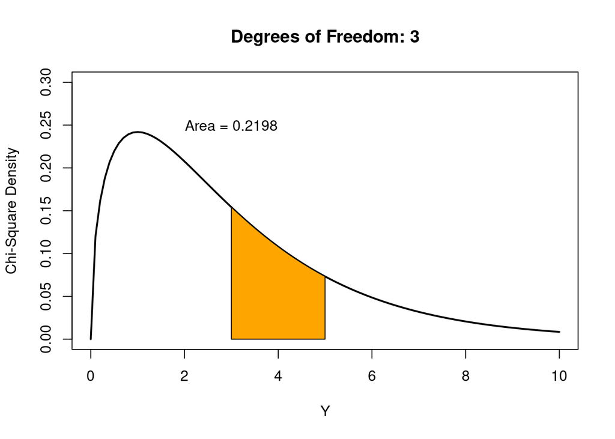

```r
curve(dchisq(x, df = 3), xlim = c(0, 10), ylim = c(0, 0.3), lwd = 2, xlab = "Y", ylab = "Chi-Square Density", main = "Degrees of Freedom: 3")
xcurve = seq(3, 5, length = 1000)
ycurve = dchisq(xcurve, df = 3)
polygon(c(3, xcurve, 5), c(0, ycurve, 0), col = "Orange")
area = round(pchisq(5, df = 3) - pchisq(3, df = 3), 4)
text(3, 0.25, paste0("Area = ", area))
```

- $Y \sim chisq(df = 20), P(10 < Y \leq 21)$

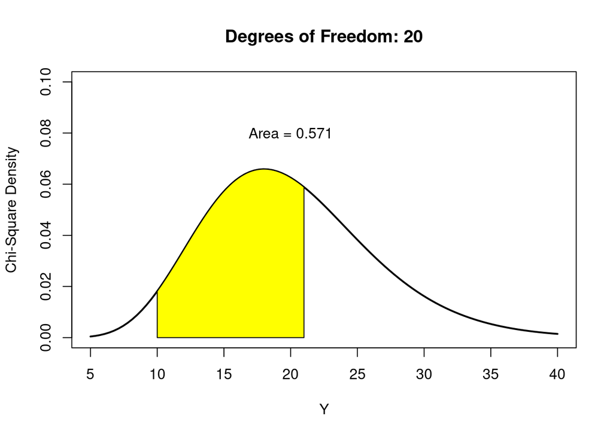

```r
curve(dchisq(x, df = 20), xlim = c(5, 40), ylim = c(0, 0.1), lwd = 2, xlab = "Y", ylab = "Chi-Square Density", main = "Degrees of Freedom: 20")
xcurve = seq(10, 21, length = 1000)
ycurve = dchisq(xcurve, df = 20)
polygon(c(10, xcurve, 21), c(0, ycurve, 0), col = "Yellow")
area = round(pchisq(21, df = 20) - pchisq(10, df = 20), 4)
text(20, 0.08, paste0("Area = ", area))
```

## Task 5

### Make four plots as above with any shape and scale combinations you wish (Using layout())

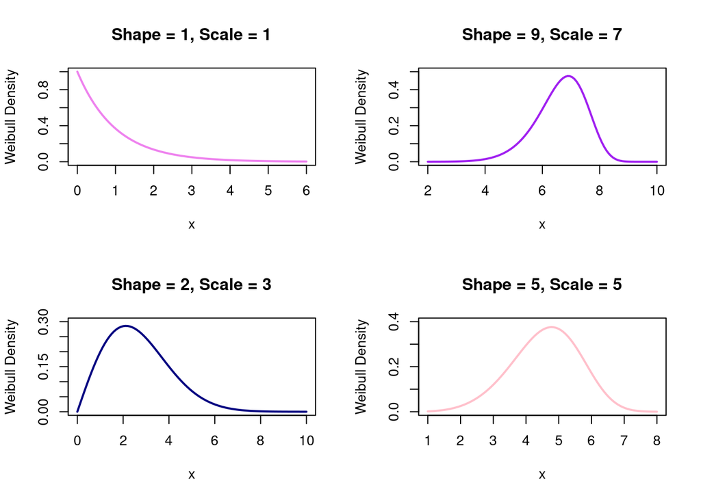

```r
layout(matrix(1:4, nr = 2, nc = 2))

curve(dweibull(x, shape = 1, scale = 1), xlim = c(0, 6), ylim = c(0, 1), col = "Violet", lwd = 2, ylab = "Weibull Density", main = "Shape = 1, Scale = 1")

curve(dweibull(x, shape = 2, scale = 3), xlim = c(0, 10), ylim = c(0, 0.3), col = "Navy", lwd = 2, ylab = "Weibull Density", main = "Shape = 2, Scale = 3")

curve(dweibull(x, shape = 9, scale = 7), xlim = c(2, 10), ylim = c(0, 0.5), col = "Purple", lwd = 2, ylab = "Weibull Density", main = "Shape = 9, Scale = 7")

curve(dweibull(x, shape = 5, scale = 5), xlim = c(1, 8), ylim = c(0, 0.4), col = "Pink", lwd = 2, ylab = "Weibull Density", main = "Shape = 5, Scale = 5")
```

### Calculate any three areas and probabilities you choose and show them on the graphs as above (separate plots).

I’ll choose the first three plots I created above:

$Y \sim weibull(shape = 1, scale = 1), P(0 \leq Y \leq 2)$

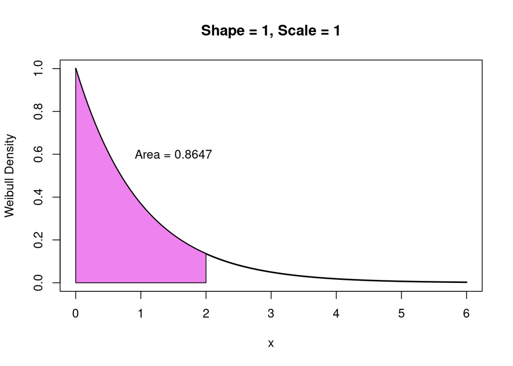

```r
curve(dweibull(x, shape = 1, scale = 1), xlim = c(0, 6), ylim = c(0, 1), lwd = 2, ylab = "Weibull Density", main = "Shape = 1, Scale = 1")
xcurve = seq(0, 2, length = 1000)
ycurve = dweibull(xcurve, shape = 1, scale = 1)
polygon(c(0, xcurve, 2), c(0, ycurve, 0), col = "Violet")
area = pweibull(2, shape = 1, scale = 1) - pweibull(0, shape = 1, scale = 1)
area = round(area, 4)
text(1.5, 0.6, paste0("Area = ", area))
```

$Y \sim weibull(shape = 2, scale = 3), P(0 \leq Y \leq 8)$

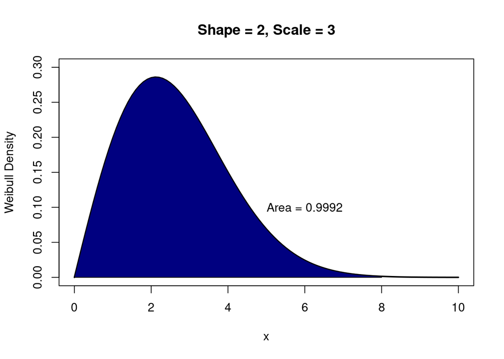

```r
curve(dweibull(x, shape = 2, scale = 3), xlim = c(0, 10), ylim = c(0, 0.3), lwd = 2, ylab = "Weibull Density", main = "Shape = 2, Scale = 3")
xcurve = seq(0, 8, length = 1000)
ycurve = dweibull(xcurve, shape = 2, scale = 3)
polygon(c(0, xcurve, 8), c(0, ycurve, 0), col = "Navy")
area = pweibull(8, shape = 2, scale = 3) - pweibull(0, shape = 2, scale = 3)
area = round(area, 4)
text(6, 0.1, paste0("Area = ", area))
```

$Y \sim weibull(shape = 9, scale = 7), P(2 \leq Y \leq 5)$

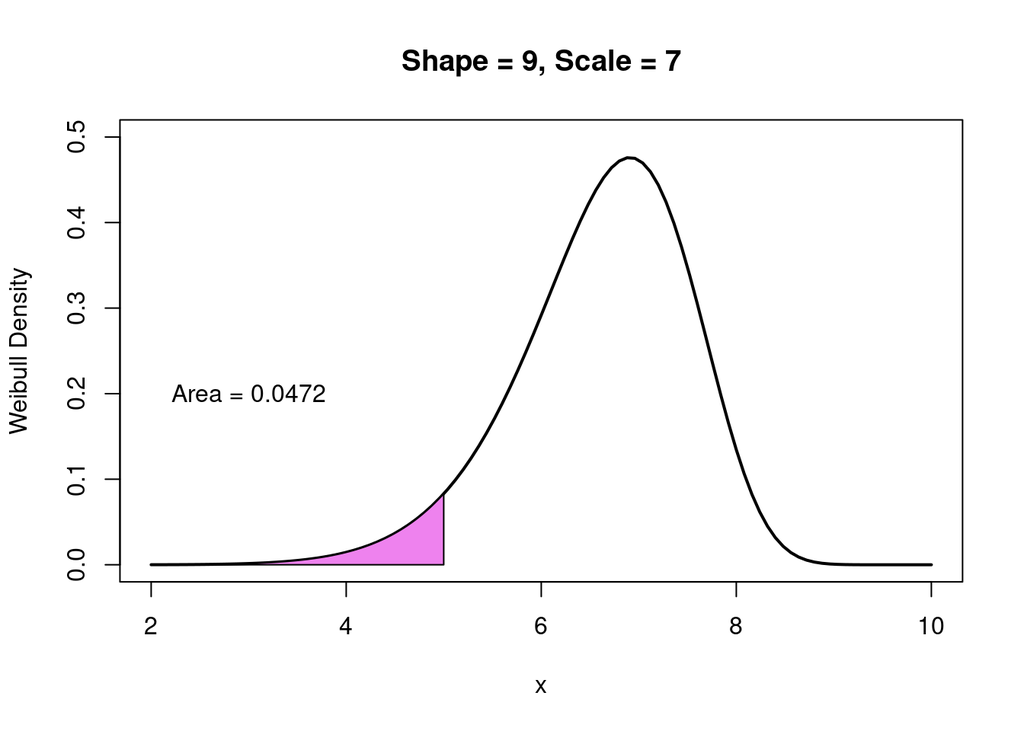

```r
curve(dweibull(x, shape = 9, scale = 7), xlim = c(2, 10), ylim = c(0, 0.5), lwd = 2, ylab = "Weibull Density", main = "Shape = 9, Scale = 7")
xcurve = seq(2, 5, length = 1000)
ycurve = dweibull(xcurve, shape = 9, scale = 7)
polygon(c(2, xcurve, 5), c(0, ycurve, 0), col = "Violet")
area = pweibull(5, shape = 9, scale = 7) - pweibull(2, shape = 9, scale = 7)
area = round(area, 4)
text(3, 0.2, paste0("Area = ", area))
```

## Task 6

### Repeat task 5 for the beta distribution.

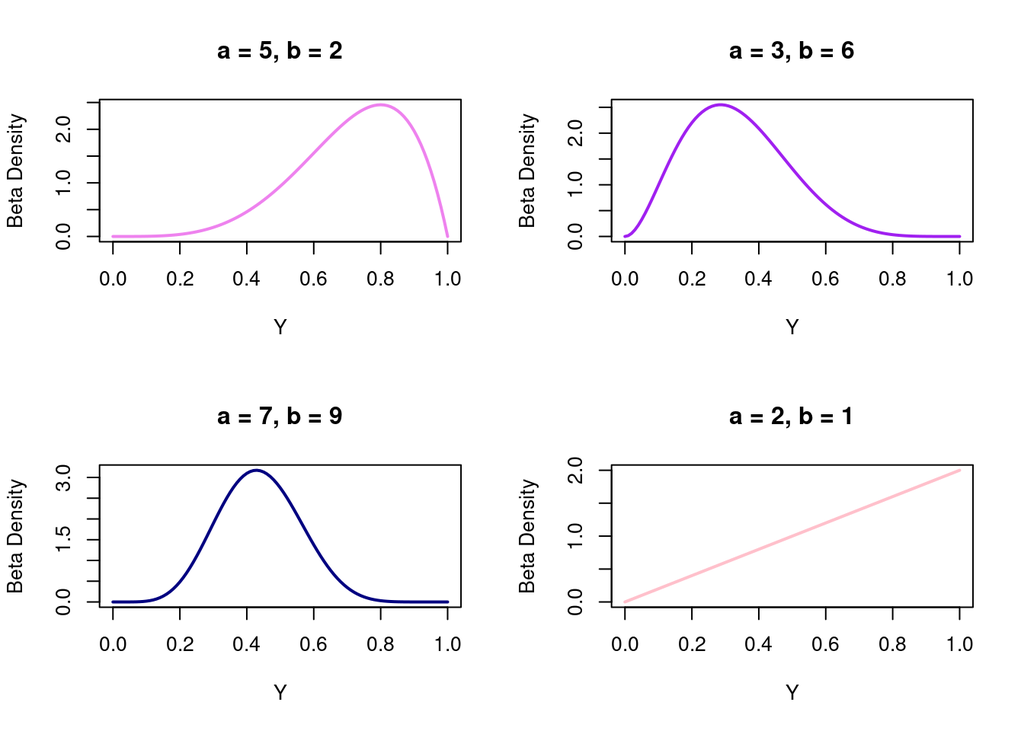

```r
layout(matrix(1:4, nr = 2, nc = 2))

curve(dbeta(x, shape1 = 5, shape2 = 2), xlim = c(0, 1), col = "Violet", lwd = 2, ylab = "Beta Density", xlab = "Y", main = "a = 5, b = 2")

curve(dbeta(x, shape1 = 7, shape2 = 9), xlim = c(0, 1), col = "Navy", lwd = 2, ylab = "Beta Density", xlab = "Y", main = "a = 7, b = 9")

curve(dbeta(x, shape1 = 3, shape2 = 6), xlim = c(0, 1), col = "Purple", lwd = 2, ylab = "Beta Density", xlab = "Y", main = "a = 3, b = 6")

curve(dbeta(x, shape1 = 2, shape2 = 1), xlim = c(0, 1), col = "Pink", lwd = 2, ylab = "Beta Density", xlab = "Y", main = "a = 2, b = 1")
```

I will again choose the first three plots I created above:

- $Y \sim beta(shape1 = 5, shape2 = 2), P(0.4 \leq Y \leq 0.6)$

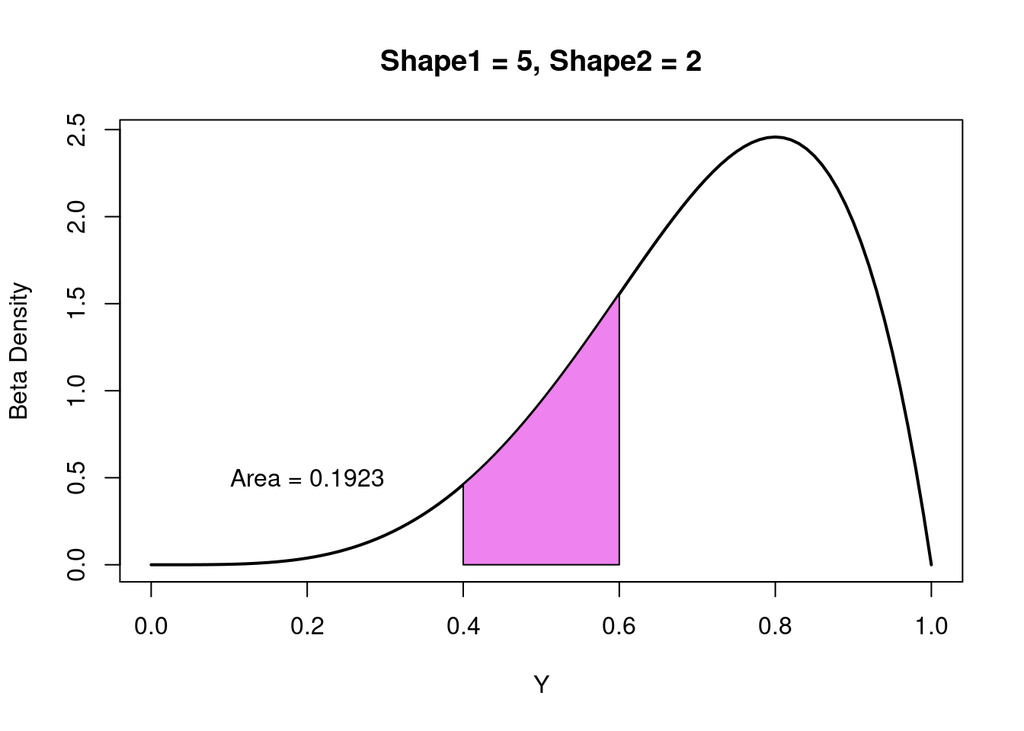

```r
curve(dbeta(x, shape1 = 5, shape2 = 2), xlim = c(0, 1), lwd = 2, ylab = "Beta Density", xlab = "Y", main = "Shape1 = 5, Shape2 = 2")
xcurve <- seq(0.4, 0.6, length = 1000)
ycurve <- dbeta(xcurve, shape1 = 5, shape2 = 2)
polygon(c(0.4, xcurve, 0.6), c(0, ycurve, 0), col = "Violet")
area <- pbeta(0.6, shape1 = 5, shape2 = 2) - pbeta(0.4, shape1 = 5, shape2 = 2)
area <- round(area, 4)
text(0.2, 0.5, paste0("Area = ", area))
```

- $Y \sim beta(shape1 = 7, shape2 = 9), P(0.6 \leq Y \leq 1.0)$

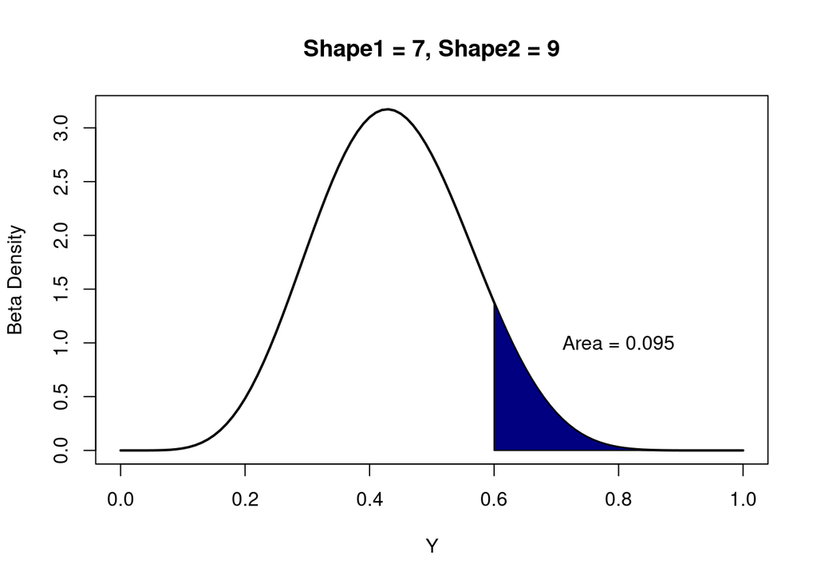

```r
curve(dbeta(x, shape1 = 7, shape2 = 9), xlim = c(0, 1), lwd = 2, ylab = "Beta Density", xlab = "Y", main = "Shape1 = 7, Shape2 = 9")
xcurve <- seq(0.6, 1.0, length = 1000)
ycurve <- dbeta(xcurve, shape1 = 7, shape2 = 9)
polygon(c(0.6, xcurve, 1.0), c(0, ycurve, 0), col = "Navy")
area <- pbeta(1.0, shape1 = 7, shape2 = 9) - pbeta(0.6, shape1 = 7, shape2 = 9)
area <- round(area, 4)
text(0.8, 1, paste0("Area = ", area))
```

- $Y \sim beta(shape1 = 3, shape2 = 6), P(0.2 \leq Y \leq 0.4)$

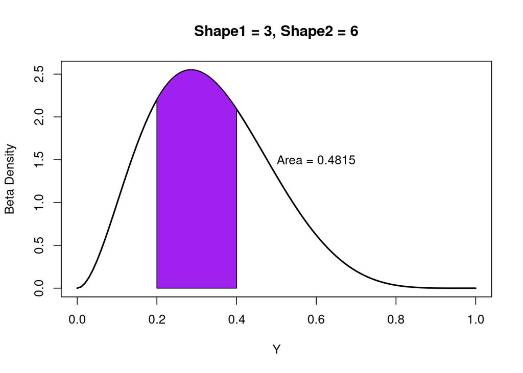

```r
curve(dbeta(x, shape1 = 3, shape2 = 6), xlim = c(0, 1), lwd = 2, ylab = "Beta Density", xlab = "Y", main = "Shape1 = 3, Shape2 = 6")
xcurve <- seq(0.2, 0.4, length = 1000)
ycurve <- dbeta(xcurve, shape1 = 3, shape2 = 6)
polygon(c(0.2, xcurve, 0.4), c(0, ycurve, 0), col = "Purple")
area <- pbeta(0.4, shape1 = 3, shape2 = 6) - pbeta(0.2, shape1 = 3, shape2 = 6)
area <- round(area, 4)
text(0.6, 1.5, paste0("Area = ", area))
```

```r
# CLEAN UP #################################################
# Clear environment
rm(list = ls())
# Clear packages
p_unload(all)  # Remove all add-ons
```

```
## The following packages have been unloaded:
## testthat, knitr, lattice, pacman
```

```r
# Clear plots
dev.off()  # But only if there IS a plot
```

```r
# Clear console
cat("\014")  # ctrl+L
```

```r
# Clear mind :)
```